# Probability and Statistics

# Lab Assignment 1: Naive Bayes Classifier

## Work breakdown

- Yarema Kertytsky: Data prep & project scaffolding
- Taras Kopach: Model implementation (Naive Bayes)
- Viktoria Markus: Evaluation, visualization, and report

## Introduction

During the first three weeks, you learned a couple of essential notions and theorems, and one of the most important among them is the **Bayes theorem**.

**Naive Bayes Classifier** is a simple algorithm, which is based on **Bayes theorem** and used for solving classification problems. **Classification problem** is a problem in which an observation has to be classified in one of the $n$ classes based on its similarity with observations in each class.

It is a **probabilistic classifier**, which means it predicts based on the probability of an observation belonging to each class. To compute it, this algorithm uses **Bayes’ formula,** that you probably already came across in **Lesson 3:**
$$\mathsf{P}(\mathrm{class}\mid
\mathrm{observation})=\frac{\mathsf{P}(\mathrm{observation}\mid\mathrm{class})\mathsf{P}(\mathrm{class})}{\mathsf{P}(\mathrm{observation})}$$

Under the strong **independence** assumption, one can calculate $\mathsf{P}(\mathrm{observation} \mid \mathrm{class})$ as
$$\mathsf{P}(\mathrm{observation}) =
\prod_{i=1}^{n} \mathsf{P}(\mathrm{feature}_i), \qquad
\mathsf{P}(\mathrm{observation} \mid \mathrm{class}) = \prod_{i=1}^{n}
\mathsf{P}(\mathrm{feature}_i \mid \mathrm{class}),$$
where $n$ is the total number of features describing a given observation (*For example, if an observation is presented as a sentence, then each word can be a feature*). Thus, $\mathsf{P}(\mathrm{class}|\mathrm{observation})$ now can be calculated as

$$\mathsf{P}(\mathrm{class} \mid
\mathrm{\mathrm{observation}}) = \mathsf{P}(\mathrm{class})\times
\prod_{i=1}^{n}\frac{\mathsf{P}(\mathrm{feature}_i\mid
\mathrm{class})}{\mathsf{P}(\mathrm{feature}_i)}\tag{1}$$

All the terms on the right-hand side can be estimated as corresponding relative frequencies using available data

**See [*this link*](https://www.javatpoint.com/machine-learning-naive-bayes-classifier) for more detailed explanations & examples :) Also you can watch [*this video*](https://youtu.be/O2L2Uv9pdDA?si=-ohkHVDuu3sLLGMq) for more examples!**

## Data description

There are 5 datasets uploaded on the cms (data.zip)

To determine your variant, take your team number from the list of teams on cms and take *mod 5* - this is the number of your data set.

- **0 - authors** This data set consists of citations of three famous writers: Edgar Alan Poe, Mary Wollstonecraft Shelley and HP Lovecraft. The task with this data set is to classify a piece of text with the author who was more likely to write it.
- **1 - discrimination** This data set consists of tweets that have discriminatory (sexism or racism) messages or of tweets that are of neutral mood. The task is to determine whether a given tweet has discriminatory mood or does not.
- **2 - fake news** This data set contains data of American news: a headline and an abstract of the article. Each piece of news is classified as fake or credible. The task is to classify the news from test.csv as credible or fake.
- **3 - sentiment** All the text messages contained in this data set are labeled with three sentiments: positive, neutral or negative. The task is to classify some text message as the one of positive mood, negative or neutral.
- **4 - spam** This last data set contains SMS messages classified as spam or non-spam (ham in the data set). The task is to determine whether a given message is spam or non-spam.

Each data set consists of two files: *train.csv* and *test.csv*. The first one is used to find the probabilities of the corresponding classes and the second one is used to test your classifier afterwards. Note that it is crucial to randomly split your data into training and testing parts to test the classifierʼs possibilities on the unseen data.

```r
# here goes a list of recommended libraries,
# though you may install other ones if they are needed


library(tidytext)
library(readr)
library(dplyr)
```

```r
library(ggplot2)
```

## Outline of the work

1. **Data pre-processing** (includes removing punctuation marks and stop words, representing each message as a bag-of-words)
2. **Data visualization** (it’s time to plot your data!)
3. **Classifier implementation** (using the training set, calculate all the conditional probabilities in formula (1))
4. **Measurements of effectiveness of your classifier** (use the results from the previous step to predict classes for messages in the testing set and measure the accuracy, precision and recall, F1 score metric etc)
5. **Conclusions**

*!! do not forget to submit both the (compiled) Rmd source file and the .html output !!*

## Data pre-processing

- Read the *.csv* data files.
- Сlear your data from punctuation or other unneeded symbols.
- Clear you data from stop words. You don’t want words as is, and, or etc. to affect your probabilities distributions, so it is a wise decision to get rid of them. Find list of stop words in the cms under the lab task.
- Represent each test message as its bag-of-words. Here: https://machinelearningmastery.com/gentle-introduction-bag-words-model/ you can find general introduction to the bag-of-words model and examples on to create it.
- It is highly recommended to get familiar with R dataframes, it would make the work much easier to do.
- Useful links:
  - https://steviep42.github.io/webscraping/book/bagofwords.html#tidytext - example of using *tidytext* to count frequencies of the words.
  - Basics of Text Mining in R: http://rstudio-pubs-static.s3.amazonaws.com/256588_57b585da6c054349825cba46685d8464.html . Note that it also includes an example on how to create a bag of words from your text document.

```r
list.files(getwd())
```

```
## [1] "data"
## [2] "intro-R.Rmd"
## [3] "Lab1_Naive_Bayes_Classifier_Templatee-4.html"
## [4] "Lab1_Naive_Bayes_Classifier_Templatee-4.Rmd"
## [5] "P-S-Lab-1"
## [6] "stop_words.txt"
```

```r
list.files("data/4-spam")
```

```
## [1] "test.csv"  "train.csv"
```

```r
test_path <- "data/4-spam/test.csv"
train_path <- "data/4-spam/train.csv"

stop_words <- read_file("stop_words.txt")
# https://stackoverflow.com/questions/27195912/why-does-strsplit-return-a-list
splitted_stop_words <- strsplit(stop_words, split='\n')
splitted_stop_words <- splitted_stop_words[[1]]
```

```r
train <-  read.csv(file = train_path, stringsAsFactors = FALSE)
test <-  read.csv(file = test_path, stringsAsFactors = FALSE)
```

```r
# Function to read data
read_data <- function(path_to_train, path_to_test) {
  return(list(
    train = read.csv(path_to_train),
    test  = read.csv(path_to_test)
  ))
}
```

```r
# Set PATH to be relative
setwd(dirname(rstudioapi::getSourceEditorContext()$path))
datasets <- read_data("data/4-spam/train.csv", "data/4-spam/test.csv")
```

```r
# PREPROCESSING FUNCTION
preprocess <- function(df) {
  # Create document IDs first
  df$message_id <- seq_len(nrow(df))

  # Basic text cleaning
  df$Message <- tolower(df$Message)
  df$Message <- gsub('[[:punct:] ]+',' ', df$Message)  # Replace punct/spaces with single space
  df$Message <- trimws(df$Message)  # Trim whitespace

  return(df)
}
```

```r
# Tokenization, BoW
create_bow_matrix <- function(df) {
  # Load stop words
  stop_wrds <- readr::read_lines("./stop_words.txt")
  stop_wrds <- trimws(stop_wrds)
  stop_wrds <- stop_wrds[nzchar(stop_wrds)] # drop empty lines
  stop_wrds <- data.frame(word = stop_wrds, stringsAsFactors = FALSE)


  df_tokens <- tidytext::unnest_tokens(df, output = "word", input = "Message",
                                       token = "words", to_lower = TRUE) # Tokenize messages


  df_tokens <- dplyr::anti_join(df_tokens, stop_wrds, by = "word") # Remove stop words


  word_counts <- dplyr::count(df_tokens, message_id, word, name = "frequency") # Count word frequencies per document


  dtm <- xtabs(frequency ~ message_id + word, data = word_counts) # Create document-term matrix (DTM)
  dtm <- as.matrix(dtm)

  return(list(
    dtm = dtm,
    tokens = df_tokens,
    word_counts = word_counts,
    labels = df[, c("message_id", "Category")]
  ))
}
```

## Data visualization

Each time you work with some data, you need to understand it before you start processing it. R has very powerful tools to make nice plots and visualization. Show what are the most common words for negative and positive examples as a histogram, word cloud etc. Be creative!

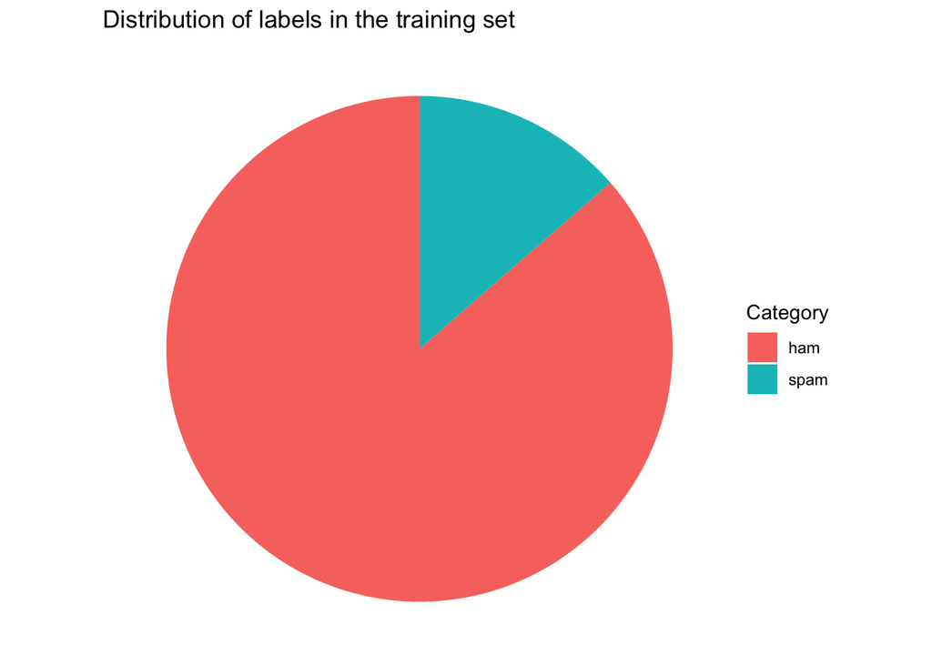

```r
# Distribution of labels in the training set
ggplot(train, aes(x = "", fill = Category)) +
  geom_bar(width = 1) +
  coord_polar(theta = "y") +
  labs(x = NULL, y = NULL, fill = "Category") +
  theme_void() +
  ggtitle("Distribution of labels in the training set")
```

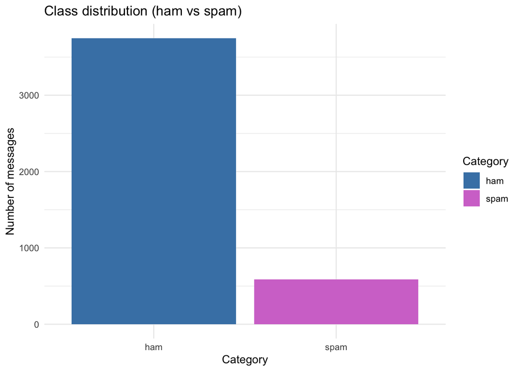

```r
# Distribution of messages to ham and scam
ggplot(create_bow_matrix(preprocess(datasets$train))$labels, aes(x = Category, fill = Category)) +
  geom_bar() +
  labs(title = "Class distribution (ham vs spam)",
       x = "Category",
       y = "Number of messages") +
  scale_fill_manual(values = c("ham" = "steelblue", "spam" = "#d378d0")) +
  theme_minimal()
```

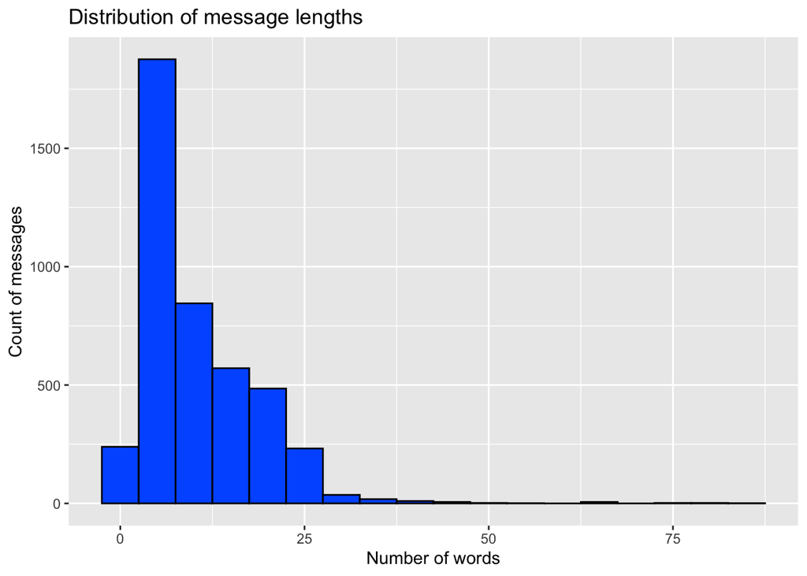

```r
# Distribution of message lengths
message_lengths <- create_bow_matrix(preprocess(datasets$train))$tokens %>%
  count(message_id)

ggplot(message_lengths, aes(x = n)) +
  geom_histogram(binwidth = 5, fill = "#005eff", color = "black") +
  labs(title = "Distribution of message lengths",
       x = "Number of words",
       y = "Count of messages")
```

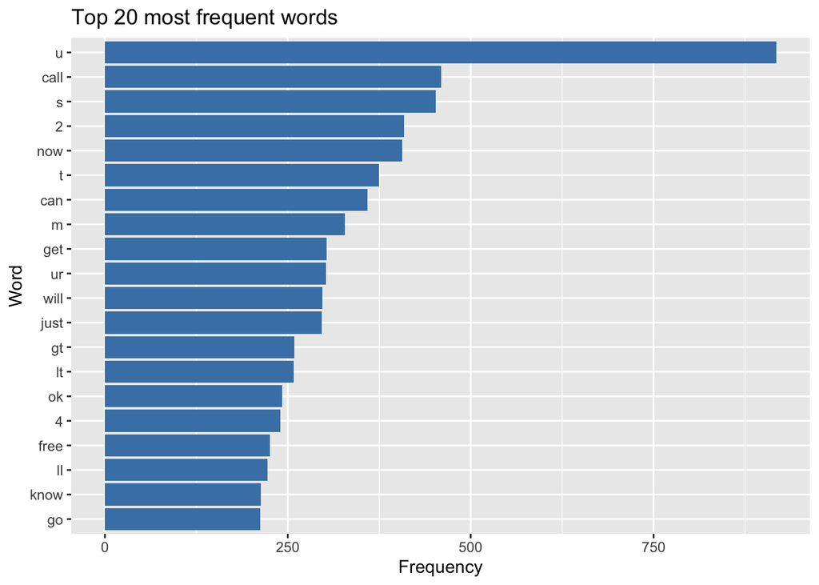

```r
# Top-20 most common words
plot_top_words <- function(tokens, n = 20) {
  top_words <- tokens %>%
    count(word, sort = TRUE) %>%
    slice_max(order_by = n, n = n)

  ggplot(top_words, aes(x = reorder(word, n), y = n)) +
    geom_col(fill = "steelblue") +
    coord_flip() +
    labs(title = paste("Top", n, "most frequent words"),
         x = "Word",
         y = "Frequency")
}
plot_top_words(create_bow_matrix(preprocess(datasets$train))$tokens, n = 20)
```

[figure not shown]

```r
# Cloud of most frequent words
library(wordcloud)
wordcloud(create_bow_matrix(preprocess(datasets$train))$tokens$word,
          max.words = 100,
          random.order = FALSE,
          colors = brewer.pal(8, "Dark2"))
```

## Classifier implementation

```r
naiveBayes <- setRefClass("naiveBayes",

      fields = list(),
      methods = list(
        fit = function(X, y)
        {
          yb <- ifelse(y == "spam", 1, 0)

          p_spam <- sum(yb) / length(yb)
          p_ham <- 1 - p_spam

          word_counts_labeled <- merge(X$word_counts, X$labels, by = "message_id")

          word_counts_spam <- dplyr::filter(word_counts_labeled, Category == "spam")
          word_counts_ham  <- dplyr::filter(word_counts_labeled, Category == "ham")

          vocab <- unique(word_counts_labeled$word)

          # P(feature | spam)
          p_spam_words <- word_counts_spam %>%
            group_by(word) %>%
            summarise(freq = sum(frequency), .groups = "drop") %>%
            right_join(data.frame(word = vocab), by = "word") %>%
            mutate(
              freq = coalesce(freq, 0),
              P = (freq + 1) / (sum(freq) + length(vocab))
            )

          # P(feature | ham)
          p_ham_words <- word_counts_ham %>%
            group_by(word) %>%
            summarise(freq = sum(frequency), .groups = "drop") %>%
            right_join(data.frame(word = vocab), by = "word") %>%
            mutate(
              freq = coalesce(freq, 0),
              P = (freq + 1) / (sum(freq) + length(vocab))
            )
          return(list(
            p_spam = p_spam,
            p_ham  = p_ham,
            p_spam_words = p_spam_words,
            p_ham_words  = p_ham_words,
            vocab = vocab
          ))
        },

        # return prediction for a single message
        predict = function(message)
        {
          words <- message$word
          freqs <- message$frequency

          pm_spam <- fit_res$p_spam
          pm_ham  <- fit_res$p_ham

          for (i in seq_along(words)) {
            w <- words[i]
            f <- freqs[i]

            # get P(word|spam)
            p_w_spam <- fit_res$p_spam_words$P[fit_res$p_spam_words$word == w]
            if (length(p_w_spam) == 0) p_w_spam <- 1 / (sum(fit_res$p_spam_words$freq) + length(fit_res$vocab))

            p_w_ham <- fit_res$p_ham_words$P[fit_res$p_ham_words$word == w]
            if (length(p_w_ham) == 0) p_w_ham <- 1 / (sum(fit_res$p_ham_words$freq) + length(fit_res$vocab))

            pm_spam <- pm_spam * (p_w_spam ^ f)
            pm_ham  <- pm_ham * (p_w_ham ^ f)
          }

          #cat("Probability of spam:", pm_spam, "\n")
          #cat("Probability of ham:", pm_ham, "\n")

          if (pm_spam > pm_ham) {
            return("spam")
          } else {
            return("ham")
          }
        },

        # score you test set so to get the understanding how well you model
        # works.
        # look at f1 score or precision and recall
        # visualize them
        # try how well your model generalizes to real world data!

      score = function(X_test, y_test)
      {
        preds <- c()

        for (i in unique(X_test$word_counts$message_id)) {
          msg <- dplyr::filter(X_test$word_counts, message_id == i)
          pred <- .self$predict(msg)
          preds <- c(preds, pred)
        }

        truths <- y_test

        TP <- sum(preds == "spam" & truths == "spam")
        TN <- sum(preds == "ham"  & truths == "ham")
        FP <- sum(preds == "spam" & truths == "ham")
        FN <- sum(preds == "ham"  & truths == "spam")

        accuracy  <- (TP + TN) / length(truths)
        precision <- ifelse((TP+FP)==0, 0, TP / (TP + FP))
        recall    <- ifelse((TP+FN)==0, 0, TP / (TP + FN))
        F1        <- ifelse((precision+recall)==0, 0, 2 * precision * recall / (precision + recall))

        return(list(
          TP = TP,
          TN = TN,
          FP = FP,
          FN = FN,
          accuracy = accuracy,
          precision = precision,
          recall = recall,
          F1 = F1,
          confusion_matrix = matrix(c(TN, FP, FN, TP), nrow = 2,
                                    dimnames = list("Actual" = c("ham","spam"),
                                                    "Predicted" = c("ham","spam")))
        ))
      }


))

train_clean <- preprocess(datasets$train)
test_clean  <- preprocess(datasets$test)

bow_train <- create_bow_matrix(train_clean)

model <- naiveBayes()
fit_res <- model$fit(bow_train, bow_train$labels$Category)
```

## Measure effectiveness of your classifier

- Note that accuracy is not always a good metric for your classifier. Look at precision and recall curves, F1 score metric.

  When evaluating the model, it’s important to understand the different types of classification results:
  - A *true positive* result is one where the model correctly predicts the positive class.
  - A *true negative* result is one where the model correctly predicts the negative class.
  - A *false positive* result is one where the model incorrectly predicts the positive class when it is actually negative.
  - A *false negative* result is one where the model incorrectly predicts the negative class when it is actually positive.

```r
#
  bow_test <- create_bow_matrix(test_clean)
  score <- model$score(bow_test, bow_test$labels$Category)
  cat('Number of true positive results:', score$TP, '\n',
      'Number of true negative results:', score$TN, '\n',
      'Number of false positive results:', score$FP, '\n',
      'Number of false negative results:', score$FN, '\n')
```

```
## Number of true positive results: 46
##  Number of true negative results: 955
##  Number of false positive results: 123
##  Number of false negative results: 112
```

```r
  cat('Accuracy:', score$accuracy)
```

```
## Accuracy: 0.8098706
```

[output not shown]

```r
cat('Precision:', score$precision)
```

```
## Precision: 0.2721893
```

[output not shown]

```r
cat('Recall:', score$recall)
```

```
## Recall: 0.2911392
```

[output not shown]

```r
cat('F1 score:', score$F1)
```

```
## F1 score: 0.2813456
```

[output not shown]

- Visualize them.

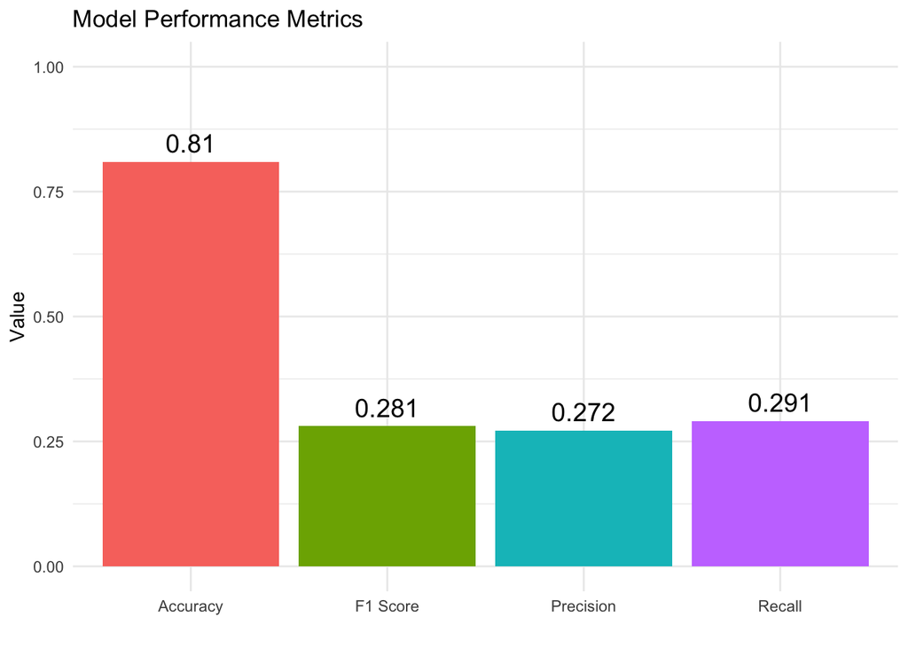

```r
metrics_f1 <- data.frame(
  Metric = c("Accuracy", "Precision", "Recall", "F1 Score"),
  Value  = c(score$accuracy, score$precision, score$recall, score$F1)
)

ggplot(metrics_f1, aes(x = Metric, y = Value, fill = Metric)) +
  geom_col(show.legend = FALSE) +
  geom_text(aes(label = round(Value, 3)), vjust = -0.5, size = 5) +
  labs(title = "Model Performance Metrics", y = "Value", x = "") +
  ylim(0, 1) +
  theme_minimal()
```

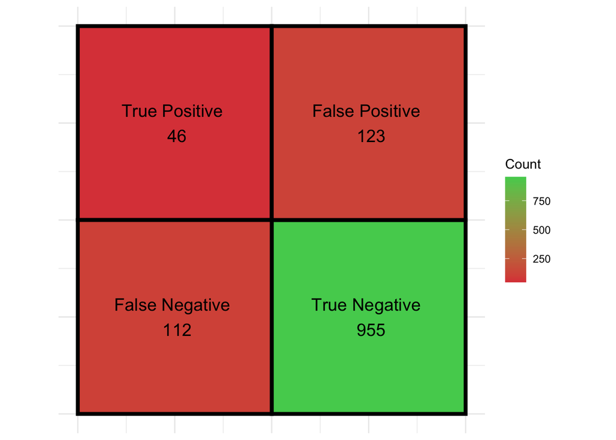

```r
metrics_predictions <- data.frame(
  Category = c("True Positive", "True Negative", "False Positive", "False Negative"),
  Count = c(score$TP, score$TN, score$FP, score$FN),
  x = c(1, 2, 2, 1),
  y = c(2, 1, 2, 1)
)

ggplot(metrics_predictions, aes(x = x, y = y, fill = Count)) +
  geom_tile(color = "black", linewidth = 1.5) +
  geom_text(aes(label = paste(Category, "\n", Count)),
            size = 5, color = "black") +
  scale_fill_gradient(low = "#dd4646", high = "#51cf5d") +
  theme_minimal() +
  theme(
    axis.title = element_blank(),
    axis.text = element_blank(),
    axis.ticks = element_blank(),
    legend.position = "right"
  ) +
  coord_fixed()
```

- Show failure cases.

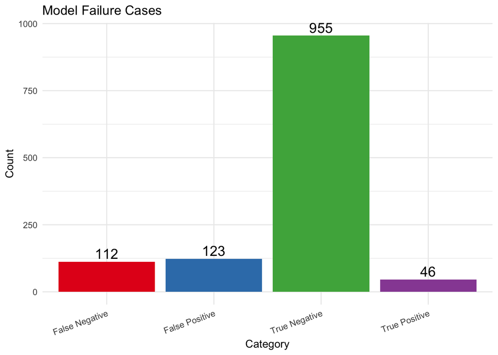

```r
metrics_predictions <- data.frame(
  Category = c("True Positive", "True Negative", "False Positive", "False Negative"),
  Count = c(score$TP, score$TN, score$FP, score$FN)
)

ggplot(metrics_predictions, aes(x = Category, y = Count, fill = Category)) +
  geom_bar(stat = "identity", show.legend = FALSE) +
  geom_text(aes(label = Count), vjust = -0.3, size = 5) +
  labs(title = "Model Failure Cases",
       x = "Category",
       y = "Count") +
  scale_fill_brewer(palette = "Set1") +
  theme_minimal() +
  theme(axis.text.x = element_text(angle = 20, hjust = 1))
```

```r
ids <- bow_test$labels$message_id

preds <- sapply(ids, function(i) {
  msg <- dplyr::filter(bow_test$word_counts, message_id == i)
  model$predict(msg)
})

results_df <- data.frame(
  message_id = ids,
  True = bow_test$labels$Category,
  Predicted = preds,
  stringsAsFactors = FALSE
)
results_df <- merge(results_df, test_clean[, c("message_id", "Message")], by = "message_id")

failure_cases <- dplyr::filter(results_df, True != Predicted)

failure_cases_fmt <- failure_cases %>%
  mutate(example = paste0('"', Message, '" – Predicted as ', Predicted,
                          ', but actually ', True, "."))
failure_cases_fmt$example[1:10]
```

```
##  [1] "\"ujhhhhhhh computer shipped out with address to sandiago and parantella lane wtf poop\" – Predicted as spam, but actually ham."
##  [2] "\"mathews or tait or edwards or anderson\" – Predicted as spam, but actually ham."
##  [3] "\"when you get free call me\" – Predicted as spam, but actually ham."
##  [4] "\"money i have won wining number 946 wot do i do next\" – Predicted as ham, but actually spam."
##  [5] "\"urgh coach hot smells of chip fat thanks again especially for the duvet not a predictive text word\" – Predicted as spam, but actually ham."
##  [6] "\"gettin rdy to ship comp\" – Predicted as spam, but actually ham."
##  [7] "\"cha quiteamuzing that\u0092scool babe probpop in cu satthen hunny 4brekkie love jen xxx psxtra lrg portions 4 me please\" – Predicted as spam, but actually ham."
##  [8] "\"have you laid your airtel line to rest\" – Predicted as spam, but actually ham."
##  [9] "\"you call him and tell now infront of them call him now\" – Predicted as spam, but actually ham."
## [10] "\"wewa is 130 iriver 255 all 128 mb\" – Predicted as spam, but actually ham."
```

## Conclusions

Summarize your work by explaining in a few sentences the points listed below.

- Describe the method implemented in general. Show what are mathematical foundations you are basing your solution on.
- List pros and cons of the method. This should include the limitations of your method, all the assumption you make about the nature of your data etc.
- Explain why accuracy is not a good choice for the base metrics for classification tasks. Why F1 score is always preferable?

## Advantages and disadvantages

### Advantages:

- Ease of implementation and interpretation.
- The ability to work effectively with data of different sizes (the larger the dataset, the more accurate the classifier).
- Speed of computation, since classification is based on simple probabilities.

### Disadvantages:

- The assumption of feature independence may be too simplistic for many problems where features are interdependent (as an intermediate solution to the problem, n-gram tokens (phrases of two, three, etc. words) can be used instead of 1-gram word tokens).
- Sensitivity to rare characteristics or classes, which can affect the accuracy of the results.
- We assumed that the dataset contained almost no errors, such as spelling mistakes, which are very common in datasets of this type. This worsened the overall performance of our algorithm, although it works better with messages written without errors.

## Accuracy and F1 score

Although the accuracy of a classifier may be quite high, this does not always indicate how well it performs in detecting positive results.

Integrity and reproducibility help us see this — integrity measures the proportion of correctly predicted positive examples, and reproducibility shows what proportion of all positive examples the model was able to recognize correctly.

The F1 score is a harmonic mean of precision and recall, which provides a balanced assessment of model quality, especially when there is class imbalance.